# PRA2 - Tipología y ciclo de los datos

Yésica Fernández Ramos

Carlos Ruiz Salvador

2022-06-07

Antes de empezar con la práctica, vamos a cargar los paquetes necesarios para la realización del ejercicio.

```r
# https://cran.r-project.org/web/packages/dplyr/index.html
if (!require('dplyr')) install.packages('dplyr'); library('dplyr')
# https://cran.r-project.org/web/packages/ggplot2/index.html
if (!require('ggplot2')) install.packages('ggplot2'); library('ggplot2')
```

# 1. Descripción del dataset

## Objetivo

El objetivo de esta práctica es el tratamiento de un dataset. En este caso, vamos a trabajar con un dataset que se encuentra en Kaggle en el siguiente enlace: https://www.kaggle.com/datasets/uciml/breast-cancer-wisconsin-data

## Descripción

El dataset contiene datos de tumores mamarios. Las características del tumor se calculan a partir de una imagen digitalizada de una masa mamaria. Las variables con las que cuenta el dataset son las siguientes:

- **id:** Identificador.
- **diagnosis:** Variable categórica que indica si el tumor es maligno (M) o benigno (B).
- **radius_mean:** Media de las distancias desde el centro a los puntos del perímetro.
- **texture_mean:** Desviación estandar de los valores de la escala de grises.
- **perimeter_mean:** Tamaño medio del tumor central.
- **area_mean:** Media del área del tumor.
- **smoothness_mean:** Media de variación local en longitudes de radio.
- **compactness_mean:** Media del perímetro^2 / área - 1.0.
- **concavity_mean:** Media de la severidad de las porciones cóncavas del contorno.
- **concave points_mean:** Media del número de porciones cóncavas del contorno.
- **symmetry_mean:** Media de la simetría.
- **fractal_dimension_mean:** Media para “aproximación a la costa” - 1.
- **radius_se:** Error estándar para la media de las distancias del centro a los puntos del perímetro.
- **texture_se:** Error estándar para la desviación estándar de los valores de escala de grises.
- **perimeter_se**: Error estándar para la media del perímetro.
- **area_se**: Error estándar para la media del área.
- **smoothness_se:** Error estándar para la variación local en longitudes de radio.
- **compactness_se:** Error estándar para perímetro^2 / área - 1.0.
- **concavity_se:** Error estándar para la severidad de las porciones cóncavas del contorno.
- **concave points_se:** Error estándar para el número de porciones cóncavas del contorno.
- **symmetry_se:** Error estándar de la media de la simetría.
- **fractal_dimension_se:** Error estándar para “aproximación de la línea de costa” - 1.
- **radius_worst:** Valor medio “peor” o mayor para la media de las distancias desde el centro hasta los puntos del perímetro.
- **texture_worst:** Valor medio “peor” o mayor para la desviación estándar de los valores de escala de grises.
- **perimeter_worst:** Valor medio “peor” o mayor para el perímetro medio.
- **area_worst:** Valor medio “peor” o mayor para la media del área.
- **smoothness_worst:** Valor medio “peor” o más grande para la variación local en longitudes de radio.
- **compactness_worst:** Valor medio “peor” o mayor para el perímetro^2/área - 1,0.
- **concavity_worst:** Valor medio “peor” o mayor para la gravedad de las partes cóncavas del contorno.
- **concave points_worst:** Valor medio “peor” o mayor para el número de porciones cóncavas del contorno.
- **symmetry_worst:** Valor medio “peor” o mayor de la media de la simetría.
- **fractal_dimension_worst:** Valor medio “peor” o mayor para “aproximación a la línea de costa” - 1.

El cáncer de mama afecta a millones de mujeres en todo el mundo. Con este dataset se podría desarrollar un algoritmo de predicción de manera que a través de los datos de una imagen digitalizada de la masa mamaria se pueda predeccir si el tumor es benigno o maligno. Ayudaría a la diagnosis del cáncer sin pruebas demasiado invasivas.

Realizamos la carga del dataset y vemos un resumen del mismo.

```r
cancer <- read.csv("data.csv", sep = ",", stringsAsFactors = TRUE)
summary(cancer)
```

```
##        id            diagnosis  radius_mean      texture_mean
##  Min.   :     8670   B:357     Min.   : 6.981   Min.   : 9.71
##  1st Qu.:   869218   M:212     1st Qu.:11.700   1st Qu.:16.17
##  Median :   906024             Median :13.370   Median :18.84
##  Mean   : 30371831             Mean   :14.127   Mean   :19.29
##  3rd Qu.:  8813129             3rd Qu.:15.780   3rd Qu.:21.80
##  Max.   :911320502             Max.   :28.110   Max.   :39.28
##  perimeter_mean     area_mean      smoothness_mean   compactness_mean
##  Min.   : 43.79   Min.   : 143.5   Min.   :0.05263   Min.   :0.01938
##  1st Qu.: 75.17   1st Qu.: 420.3   1st Qu.:0.08637   1st Qu.:0.06492
##  Median : 86.24   Median : 551.1   Median :0.09587   Median :0.09263
##  Mean   : 91.97   Mean   : 654.9   Mean   :0.09636   Mean   :0.10434
##  3rd Qu.:104.10   3rd Qu.: 782.7   3rd Qu.:0.10530   3rd Qu.:0.13040
##  Max.   :188.50   Max.   :2501.0   Max.   :0.16340   Max.   :0.34540
##  concavity_mean    concave.points_mean symmetry_mean    fractal_dimension_mean
##  Min.   :0.00000   Min.   :0.00000     Min.   :0.1060   Min.   :0.04996
##  1st Qu.:0.02956   1st Qu.:0.02031     1st Qu.:0.1619   1st Qu.:0.05770
##  Median :0.06154   Median :0.03350     Median :0.1792   Median :0.06154
##  Mean   :0.08880   Mean   :0.04892     Mean   :0.1812   Mean   :0.06280
##  3rd Qu.:0.13070   3rd Qu.:0.07400     3rd Qu.:0.1957   3rd Qu.:0.06612
##  Max.   :0.42680   Max.   :0.20120     Max.   :0.3040   Max.   :0.09744
##    radius_se        texture_se      perimeter_se       area_se
##  Min.   :0.1115   Min.   :0.3602   Min.   : 0.757   Min.   :  6.802
##  1st Qu.:0.2324   1st Qu.:0.8339   1st Qu.: 1.606   1st Qu.: 17.850
##  Median :0.3242   Median :1.1080   Median : 2.287   Median : 24.530
##  Mean   :0.4052   Mean   :1.2169   Mean   : 2.866   Mean   : 40.337
##  3rd Qu.:0.4789   3rd Qu.:1.4740   3rd Qu.: 3.357   3rd Qu.: 45.190
##  Max.   :2.8730   Max.   :4.8850   Max.   :21.980   Max.   :542.200
##  smoothness_se      compactness_se      concavity_se     concave.points_se
##  Min.   :0.001713   Min.   :0.002252   Min.   :0.00000   Min.   :0.000000
##  1st Qu.:0.005169   1st Qu.:0.013080   1st Qu.:0.01509   1st Qu.:0.007638
##  Median :0.006380   Median :0.020450   Median :0.02589   Median :0.010930
##  Mean   :0.007041   Mean   :0.025478   Mean   :0.03189   Mean   :0.011796
##  3rd Qu.:0.008146   3rd Qu.:0.032450   3rd Qu.:0.04205   3rd Qu.:0.014710
##  Max.   :0.031130   Max.   :0.135400   Max.   :0.39600   Max.   :0.052790
##   symmetry_se       fractal_dimension_se  radius_worst   texture_worst
##  Min.   :0.007882   Min.   :0.0008948    Min.   : 7.93   Min.   :12.02
##  1st Qu.:0.015160   1st Qu.:0.0022480    1st Qu.:13.01   1st Qu.:21.08
##  Median :0.018730   Median :0.0031870    Median :14.97   Median :25.41
##  Mean   :0.020542   Mean   :0.0037949    Mean   :16.27   Mean   :25.68
```

[output cut: 8 more lines]

```
##  Max.   :251.20   Max.   :4254.0   Max.   :0.22260   Max.   :1.05800
##  concavity_worst  concave.points_worst symmetry_worst   fractal_dimension_worst
##  Min.   :0.0000   Min.   :0.00000      Min.   :0.1565   Min.   :0.05504
##  1st Qu.:0.1145   1st Qu.:0.06493      1st Qu.:0.2504   1st Qu.:0.07146
##  Median :0.2267   Median :0.09993      Median :0.2822   Median :0.08004
##  Mean   :0.2722   Mean   :0.11461      Mean   :0.2901   Mean   :0.08395
##  3rd Qu.:0.3829   3rd Qu.:0.16140      3rd Qu.:0.3179   3rd Qu.:0.09208
##  Max.   :1.2520   Max.   :0.29100      Max.   :0.6638   Max.   :0.20750
##     X
##  Mode:logical
##  NA's:569
##
##
##
##
```

```r
head(cancer)
```

|  | id | diagnosis | radius_mean | texture_mean | perimeter_mean | area_mean | smoothness_mean | compactness_mean | concavity_mean | concave.points_mean | symmetry_mean | fractal_dimension_mean | radius_se | texture_se | perimeter_se | area_se | smoothness_se | compactness_se | concavity_se | concave.points_se | symmetry_se | fractal_dimension_se | radius_worst | texture_worst | perimeter_worst | area_worst | smoothness_worst | compactness_worst | concavity_worst | … |
| --- | --- | --- | --- | --- | --- | --- | --- | --- | --- | --- | --- | --- | --- | --- | --- | --- | --- | --- | --- | --- | --- | --- | --- | --- | --- | --- | --- | --- | --- | --- |
| 1 | 842302 | M | 17.99 | 10.38 | 122.80 | 1001.0 | 0.11840 | 0.27760 | 0.3001 | 0.14710 | 0.2419 | 0.07871 | 1.0950 | 0.9053 | 8.589 | 153.40 | 0.006399 | 0.04904 | 0.05373 | 0.01587 | 0.03003 | 0.006193 | 25.38 | 17.33 | 184.60 | 2019.0 | 0.1622 | 0.6656 | 0.7119 | … |
| 2 | 842517 | M | 20.57 | 17.77 | 132.90 | 1326.0 | 0.08474 | 0.07864 | 0.0869 | 0.07017 | 0.1812 | 0.05667 | 0.5435 | 0.7339 | 3.398 | 74.08 | 0.005225 | 0.01308 | 0.01860 | 0.01340 | 0.01389 | 0.003532 | 24.99 | 23.41 | 158.80 | 1956.0 | 0.1238 | 0.1866 | 0.2416 | … |
| 3 | 84300903 | M | 19.69 | 21.25 | 130.00 | 1203.0 | 0.10960 | 0.15990 | 0.1974 | 0.12790 | 0.2069 | 0.05999 | 0.7456 | 0.7869 | 4.585 | 94.03 | 0.006150 | 0.04006 | 0.03832 | 0.02058 | 0.02250 | 0.004571 | 23.57 | 25.53 | 152.50 | 1709.0 | 0.1444 | 0.4245 | 0.4504 | … |
| 4 | 84348301 | M | 11.42 | 20.38 | 77.58 | 386.1 | 0.14250 | 0.28390 | 0.2414 | 0.10520 | 0.2597 | 0.09744 | 0.4956 | 1.1560 | 3.445 | 27.23 | 0.009110 | 0.07458 | 0.05661 | 0.01867 | 0.05963 | 0.009208 | 14.91 | 26.50 | 98.87 | 567.7 | 0.2098 | 0.8663 | 0.6869 | … |
| 5 | 84358402 | M | 20.29 | 14.34 | 135.10 | 1297.0 | 0.10030 | 0.13280 | 0.1980 | 0.10430 | 0.1809 | 0.05883 | 0.7572 | 0.7813 | 5.438 | 94.44 | 0.011490 | 0.02461 | 0.05688 | 0.01885 | 0.01756 | 0.005115 | 22.54 | 16.67 | 152.20 | 1575.0 | 0.1374 | 0.2050 | 0.4000 | … |
| 6 | 843786 | M | 12.45 | 15.70 | 82.57 | 477.1 | 0.12780 | 0.17000 | 0.1578 | 0.08089 | 0.2087 | 0.07613 | 0.3345 | 0.8902 | 2.217 | 27.19 | 0.007510 | 0.03345 | 0.03672 | 0.01137 | 0.02165 | 0.005082 | 15.47 | 23.75 | 103.40 | 741.6 | 0.1791 | 0.5249 | 0.5355 | … |

# 2. Integración y selección de datos.

Para la realización del estudio se van a descartar las variables que van a utilizar todas las variables con las que cuenta el dataset. Después de realizar la limpieza y el análisis, igual se descarta alguna variable para la creación del modelo si se ve que estas no son útiles para el modelo.

# 3. Limpieza de los datos

## 3.1. ¿Los datos contienen ceros o elementos vacíos?

En primer lugar, se va a observar si el dataset contiene NA o valores nulos. En este caso, como se puede observar en el resumen, todos las varaibles son completas, no contienen NA. Al realizar la carga de datos se ha añadido una columna “X” que contiene NA para todas las observaciones. Por lo tanto, se va a eliminar esta columna.

```r
cancer <- cancer[, !names(cancer) %in% c("X")]
```

## 3.2. Identifica y gestiona los valores extremos.

Se procede a evaluar ahora los outliers de las variables. Para ello, se crearán gráficos de cajas y se estudiarán los valores extremos.

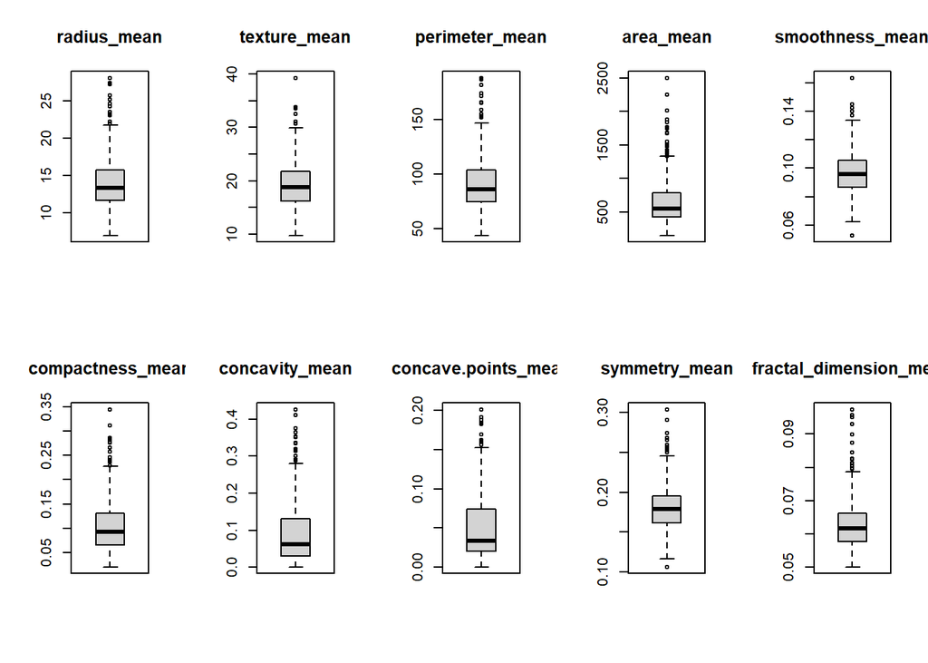

```r
par(mfrow = c(2, 5))
g_radius_mean <- boxplot(cancer$radius_mean, main="radius_mean")
g_texture_mean <- boxplot(cancer$texture_mean, main="texture_mean")
g_perimeter_mean <- boxplot(cancer$perimeter_mean, main="perimeter_mean")
g_area_mean <- boxplot(cancer$area_mean, main ="area_mean")
g_smoothness_mean <- boxplot(cancer$smoothness_mean, main="smoothness_mean")
g_compactness_mean <- boxplot(cancer$compactness_mean, main="compactness_mean")
g_concavity_mean     <- boxplot(cancer$concavity_mean    , main="concavity_mean    ")
g_concave.points_mean <- boxplot(cancer$concave.points_mean, main="concave.points_mean")
g_symmetry_mean <- boxplot(cancer$symmetry_mean, main="symmetry_mean")
g_fractal_dimension_mean <- boxplot(cancer$fractal_dimension_mean, main="fractal_dimension_mean")
```

Al observar estas 10 variables se puede ver que existen outliers para todas ellas, al rededor de 10 valores cada variable, más o menos. Como el conjunto de datos ya cuenta con pocas observaciones se van a sustituir estos valores con la media de las variables. Para ello, primero se sustituyen por NA para que estos valores no influyan a la hora del cálculo de la media.

```r
cancer$radius_mean <- ifelse(cancer$radius_mean %in% g_radius_mean$out,NA, cancer$radius_mean)
cancer$texture_mean <- ifelse(cancer$texture_mean %in% g_texture_mean$out, NA, cancer$texture_mean)
cancer$perimeter_mean <- ifelse(cancer$perimeter_mean %in% g_perimeter_mean$out, NA, cancer$perimeter_mean)
cancer$area_mean <- ifelse(cancer$area_mean %in% g_area_mean$out, NA, cancer$area_mean)
cancer$smoothness_mean <- ifelse(cancer$smoothness_mean %in% g_smoothness_mean$out, NA, cancer$smoothness_mean)
cancer$compactness_mean <- ifelse(cancer$compactness_mean %in% g_compactness_mean$out, NA, cancer$compactness_mean)
cancer$concavity_mean <- ifelse(cancer$concavity_mean %in% g_concavity_mean$out, NA, cancer$concavity_mean)
cancer$concave.points_mean <- ifelse(cancer$concave.points_mean %in% g_concave.points_mean$out, NA, cancer$concave.points_mean)
cancer$symmetry_mean <- ifelse(cancer$symmetry_mean %in% g_symmetry_mean$out, NA, cancer$symmetry_mean)
cancer$fractal_dimension_mean <- ifelse(cancer$fractal_dimension_mean %in% g_fractal_dimension_mean$out, NA, cancer$fractal_dimension_mean)
```

Seguimos observando los valores extremos.

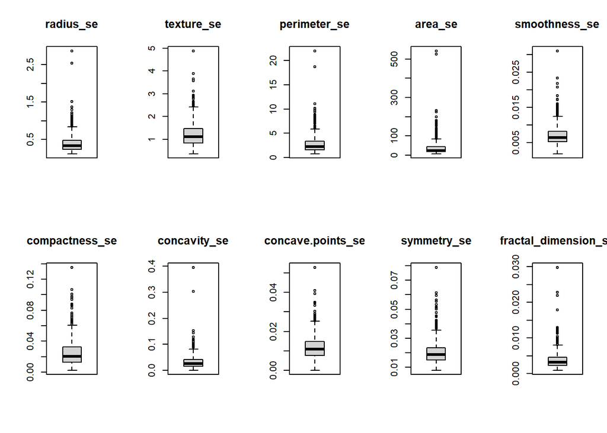

```r
par(mfrow = c(2, 5))
g_radius_se <- boxplot(cancer$radius_se, main= "radius_se")
g_texture_se <- boxplot(cancer$texture_se, main="texture_se")
g_perimeter_se <- boxplot(cancer$perimeter_se, main="perimeter_se")
g_area_se <- boxplot(cancer$area_se, main ="area_se")
g_smoothness_se <- boxplot(cancer$smoothness_se, main="smoothness_se")
g_compactness_se <- boxplot(cancer$compactness_se, main = "compactness_se")
g_concavity_se <- boxplot(cancer$concavity_se, main = "concavity_se")
g_concave.points_se <- boxplot(cancer$concave.points_se, main="concave.points_se")
g_symmetry_se <- boxplot(cancer$symmetry_se, main="symmetry_se")
g_fractal_dimension_se <- boxplot(cancer$fractal_dimension_se, main="fractal_dimension_se")
```

Para estas variables se realiza lo mismo que en el caso anterior, se sustituyen por NA para posteriormente sustituírlos por la media.

```r
cancer$radius_se <- ifelse(cancer$radius_se %in% g_radius_se$out, NA, cancer$radius_se)
cancer$texture_se <- ifelse(cancer$texture_se %in% g_texture_se$out, NA, cancer$texture_se)
cancer$perimeter_se <- ifelse(cancer$perimeter_se %in% g_perimeter_se$out, NA, cancer$perimeter_se)
cancer$area_se <- ifelse(cancer$area_se %in% g_area_se$out, NA, cancer$area_se)
cancer$smoothness_se <- ifelse(cancer$smoothness_se %in% g_smoothness_se$out, NA, cancer$smoothness_se)
cancer$compactness_se <- ifelse(cancer$compactness_se %in% g_compactness_se$out, NA, cancer$compactness_se)
cancer$concavity_se <- ifelse(cancer$concavity_se %in% g_concavity_se$out, NA, cancer$concavity_se)
cancer$concave.points_se <- ifelse(cancer$concave.points_se %in% g_concave.points_se$out, NA, cancer$concave.points_se)
cancer$symmetry_se <- ifelse(cancer$symmetry_se %in% g_symmetry_se$out, NA, cancer$symmetry_se)
cancer$fractal_dimension_se <- ifelse(cancer$fractal_dimension_se %in% g_fractal_dimension_se$out, NA, cancer$fractal_dimension_se)
```

Se ven ahora los valores extremos de las últimas variables.

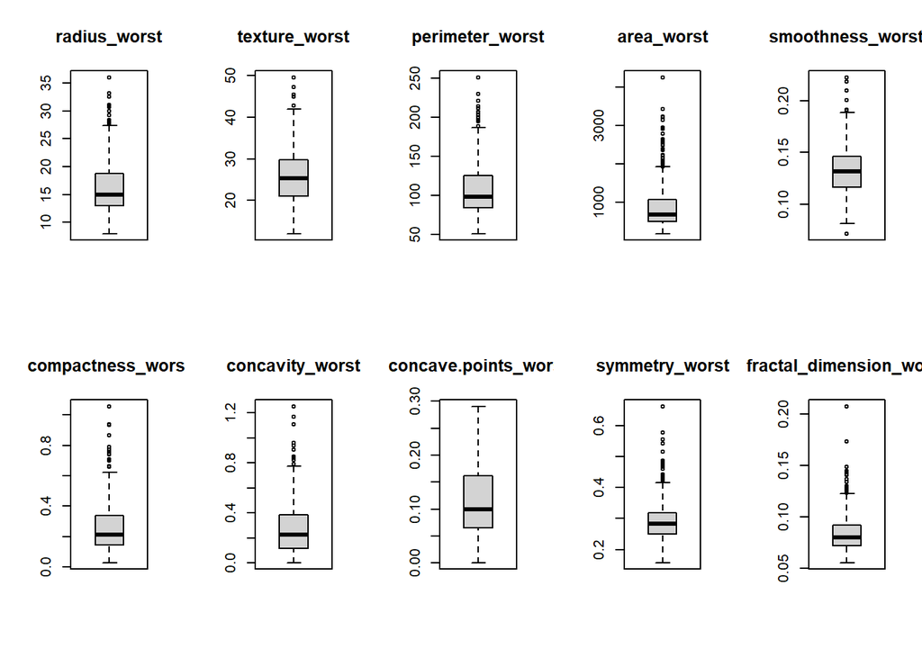

```r
par(mfrow = c(2, 5))
g_radius_worst    <- boxplot(cancer$radius_worst, main = "radius_worst" )
g_texture_worst <- boxplot(cancer$texture_worst, main="texture_worst")
g_perimeter_worst <- boxplot(cancer$perimeter_worst, main="perimeter_worst")
g_area_worst <- boxplot(cancer$area_worst, main="area_worst")
g_smoothness_worst <- boxplot(cancer$smoothness_worst, main="smoothness_worst")
g_compactness_worst <- boxplot(cancer$compactness_worst, main="compactness_worst")
g_concavity_worst <- boxplot(cancer$concavity_worst, main="concavity_worst")
g_concave.points_worst <- boxplot(cancer$concave.points_worst, main="concave.points_worst")
g_symmetry_worst <- boxplot(cancer$symmetry_worst, main="symmetry_worst")
g_fractal_dimension_worst <- boxplot(cancer$fractal_dimension_worst, main="fractal_dimension_worst")
```

```r
cancer$radius_worst <- ifelse(cancer$radius_worst %in% g_radius_worst$out, NA, cancer$radius_worst)
cancer$texture_worst <- ifelse(cancer$texture_worst %in% g_texture_worst$out, NA, cancer$texture_worst)
cancer$perimeter_worst <- ifelse(cancer$perimeter_worst %in% g_perimeter_worst$out, NA, cancer$perimeter_worst)
cancer$area_worst <- ifelse(cancer$area_worst %in% g_area_worst$out, NA, cancer$area_worst)
cancer$smoothness_worst <- ifelse(cancer$smoothness_worst %in% g_smoothness_worst$out, NA, cancer$smoothness_worst)
cancer$compactness_worst <- ifelse(cancer$compactness_worst %in% g_compactness_worst$out, NA, cancer$compactness_worst)
cancer$concavity_worst <- ifelse(cancer$concavity_worst %in% g_concavity_worst$out, NA, cancer$concavity_worst)
cancer$concave.points_worst <- ifelse(cancer$concave.points_worst %in% g_concave.points_worst$out, NA, cancer$concave.points_worst)
cancer$symmetry_worst <- ifelse(cancer$symmetry_worst %in% g_symmetry_worst$out, NA, cancer$symmetry_worst)
cancer$fractal_dimension_worst <- ifelse(cancer$fractal_dimension_worst %in% g_fractal_dimension_worst$out, NA, cancer$fractal_dimension_worst)
```

Ahora podemos sustituir los valores NA por las medias de las variables.

```r
cancer$radius_mean <- ifelse(is.na(cancer$radius_mean), mean(na.omit(cancer$radius_mean)), cancer$radius_mean)
cancer$texture_mean <- ifelse(is.na(cancer$texture_mean),mean(na.omit(cancer$texture_mean)), cancer$texture_mean)
cancer$perimeter_mean <- ifelse(is.na(cancer$perimeter_mean),mean(na.omit(cancer$perimeter_mean)), cancer$perimeter_mean)
cancer$area_mean <- ifelse(is.na(cancer$area_mean),mean(na.omit(cancer$area_mean)), cancer$area_mean)
cancer$smoothness_mean <- ifelse(is.na(cancer$smoothness_mean), mean(na.omit(cancer$smoothness_mean)), cancer$smoothness_mean)
cancer$compactness_mean <- ifelse(is.na(cancer$compactness_mean), mean(na.omit(cancer$compactness_mean)), cancer$compactness_mean)
cancer$concavity_mean <- ifelse(is.na(cancer$concavity_mean), mean(na.omit(cancer$concavity_mean)), cancer$concavity_mean)
cancer$concave.points_mean <- ifelse(is.na(cancer$concave.points_mean),mean(na.omit(cancer$concave.points_mean)), cancer$concave.points_mean)
cancer$symmetry_mean <- ifelse(is.na(cancer$symmetry_mean), mean(na.omit(cancer$symmetry_mean)), cancer$symmetry_mean)
cancer$fractal_dimension_mean <- ifelse(is.na(cancer$fractal_dimension_mean),mean(na.omit(cancer$fractal_dimension_mean)), cancer$fractal_dimension_mean)

cancer$radius_se <- ifelse(is.na(cancer$radius_se), mean(na.omit(cancer$radius_se)), cancer$radius_se)
cancer$texture_se <- ifelse(is.na(cancer$texture_se), mean(na.omit(cancer$texture_se)), cancer$texture_se)
cancer$perimeter_se <- ifelse(is.na(cancer$perimeter_se), mean(na.omit(cancer$perimeter_se)), cancer$perimeter_se)
cancer$area_se <- ifelse(is.na(cancer$area_se), mean(na.omit(cancer$area_se)), cancer$area_se)
cancer$smoothness_se <- ifelse(is.na(cancer$smoothness_se), mean(na.omit(cancer$smoothness_se)), cancer$smoothness_se)
cancer$compactness_se <- ifelse(is.na(cancer$compactness_se), mean(na.omit(cancer$compactness_se)), cancer$compactness_se)
cancer$concavity_se <- ifelse(is.na(cancer$concavity_se), mean(na.omit(cancer$concavity_se)), cancer$concavity_se)
cancer$concave.points_se <- ifelse(is.na(cancer$concave.points_se), mean(na.omit(cancer$concave.points_se)), cancer$concave.points_se)
cancer$symmetry_se <- ifelse(is.na(cancer$symmetry_se), mean(na.omit(cancer$symmetry_se)), cancer$symmetry_se)
cancer$fractal_dimension_se <- ifelse(is.na(cancer$fractal_dimension_se), mean(na.omit(cancer$fractal_dimension_se)), cancer$fractal_dimension_se)

cancer$radius_worst <- ifelse(is.na(cancer$radius_worst), mean(na.omit(cancer$radius_worst)), cancer$radius_worst)
cancer$texture_worst <- ifelse(is.na(cancer$texture_worst), mean(na.omit(cancer$texture_worst)), cancer$texture_worst)
cancer$perimeter_worst <- ifelse(is.na(cancer$perimeter_worst), mean(na.omit(cancer$perimeter_worst)), cancer$perimeter_worst)
cancer$area_worst <- ifelse(is.na(cancer$area_worst), mean(na.omit(cancer$area_worst)), cancer$area_worst)
cancer$smoothness_worst <- ifelse(is.na(cancer$smoothness_worst), mean(na.omit(cancer$smoothness_worst)), cancer$smoothness_worst)
cancer$compactness_worst <- ifelse(is.na(cancer$compactness_worst), mean(na.omit(cancer$compactness_worst)), cancer$compactness_worst)
cancer$concavity_worst <- ifelse(is.na(cancer$concavity_worst), mean(na.omit(cancer$concavity_worst)), cancer$concavity_worst)
cancer$concave.points_worst <- ifelse(is.na(cancer$concave.points_worst), mean(na.omit(cancer$concave.points_worst)), cancer$concave.points_worst)
cancer$symmetry_worst <- ifelse(is.na(cancer$symmetry_worst),mean(na.omit(cancer$symmetry_worst)), cancer$symmetry_worst)
cancer$fractal_dimension_worst <- ifelse(is.na(cancer$fractal_dimension_worst), mean(na.omit(cancer$fractal_dimension_worst)), cancer$fractal_dimension_worst)
```

De esta manera ya está realizado el tratamiento de los valores extremos.

# 4. Análisis de los datos

## 4.1. Selección de los grupos de datos que se quieren analizar/comparar

Para empezar el análisis, vamos a ver unos descriptivos básicos de los datos.

```r
summary(cancer)
```

```
##        id            diagnosis  radius_mean      texture_mean
##  Min.   :     8670   B:357     Min.   : 6.981   Min.   : 9.71
##  1st Qu.:   869218   M:212     1st Qu.:11.700   1st Qu.:16.17
##  Median :   906024             Median :13.370   Median :18.84
##  Mean   : 30371831             Mean   :13.865   Mean   :19.12
##  3rd Qu.:  8813129             3rd Qu.:15.460   3rd Qu.:21.60
##  Max.   :911320502             Max.   :21.750   Max.   :29.97
##  perimeter_mean     area_mean      smoothness_mean   compactness_mean
##  Min.   : 43.79   Min.   : 143.5   Min.   :0.06251   Min.   :0.01938
##  1st Qu.: 75.17   1st Qu.: 420.3   1st Qu.:0.08641   1st Qu.:0.06492
##  Median : 86.24   Median : 551.1   Median :0.09592   Median :0.09263
##  Mean   : 90.24   Mean   : 608.2   Mean   :0.09600   Mean   :0.09959
##  3rd Qu.:102.40   3rd Qu.: 710.6   3rd Qu.:0.10490   3rd Qu.:0.12750
##  Max.   :147.30   Max.   :1326.0   Max.   :0.13350   Max.   :0.22840
##  concavity_mean    concave.points_mean symmetry_mean    fractal_dimension_mean
##  Min.   :0.00000   Min.   :0.00000     Min.   :0.1167   Min.   :0.04996
##  1st Qu.:0.02956   1st Qu.:0.02031     1st Qu.:0.1620   1st Qu.:0.05770
##  Median :0.06154   Median :0.03350     Median :0.1792   Median :0.06154
##  Mean   :0.08055   Mean   :0.04666     Mean   :0.1792   Mean   :0.06217
##  3rd Qu.:0.11680   3rd Qu.:0.06847     3rd Qu.:0.1943   3rd Qu.:0.06569
##  Max.   :0.28100   Max.   :0.15200     Max.   :0.2459   Max.   :0.07871
##    radius_se        texture_se      perimeter_se      area_se
##  Min.   :0.1115   Min.   :0.3602   Min.   :0.757   Min.   : 6.802
##  1st Qu.:0.2324   1st Qu.:0.8339   1st Qu.:1.606   1st Qu.:17.850
##  Median :0.3242   Median :1.1080   Median :2.287   Median :24.530
##  Mean   :0.3515   Mean   :1.1530   Mean   :2.464   Mean   :28.351
##  3rd Qu.:0.4212   3rd Qu.:1.4100   3rd Qu.:2.974   3rd Qu.:31.980
##  Max.   :0.8426   Max.   :2.4260   Max.   :5.865   Max.   :83.500
##  smoothness_se      compactness_se      concavity_se     concave.points_se
##  Min.   :0.001713   Min.   :0.002252   Min.   :0.00000   Min.   :0.000000
##  1st Qu.:0.005169   1st Qu.:0.013080   1st Qu.:0.01509   1st Qu.:0.007638
##  Median :0.006380   Median :0.020450   Median :0.02589   Median :0.010930
##  Mean   :0.006556   Mean   :0.022649   Mean   :0.02793   Mean   :0.011128
##  3rd Qu.:0.007702   3rd Qu.:0.030260   3rd Qu.:0.03863   3rd Qu.:0.014030
##  Max.   :0.012430   Max.   :0.060630   Max.   :0.08232   Max.   :0.025270
##   symmetry_se       fractal_dimension_se  radius_worst   texture_worst
##  Min.   :0.007882   Min.   :0.0008948    Min.   : 7.93   Min.   :12.02
##  1st Qu.:0.015160   1st Qu.:0.0022480    1st Qu.:13.01   1st Qu.:21.08
##  Median :0.018730   Median :0.0031870    Median :14.97   Median :25.41
##  Mean   :0.019254   Mean   :0.0033619    Mean   :15.84   Mean   :25.50
##  3rd Qu.:0.022030   3rd Qu.:0.0041740    3rd Qu.:17.79   3rd Qu.:29.41
##  Max.   :0.035460   Max.   :0.0080150    Max.   :27.32   Max.   :41.85
##  perimeter_worst    area_worst     smoothness_worst  compactness_worst
##  Min.   : 50.41   Min.   : 185.2   Min.   :0.08125   Min.   :0.02729
##  1st Qu.: 84.11   1st Qu.: 515.3   1st Qu.:0.11660   1st Qu.:0.14720
##  Median : 97.66   Median : 686.5   Median :0.13140   Median :0.21190
##  Mean   :104.52   Mean   : 778.7   Mean   :0.13170   Mean   :0.23897
##  3rd Qu.:120.30   3rd Qu.: 906.6   3rd Qu.:0.14510   3rd Qu.:0.31500
##  Max.   :186.80   Max.   :1933.0   Max.   :0.18830   Max.   :0.62470
##  concavity_worst  concave.points_worst symmetry_worst   fractal_dimension_worst
##  Min.   :0.0000   Min.   :0.00000      Min.   :0.1565   Min.   :0.05504
##  1st Qu.:0.1145   1st Qu.:0.06493      1st Qu.:0.2504   1st Qu.:0.07146
##  Median :0.2267   Median :0.09993      Median :0.2821   Median :0.08004
##  Mean   :0.2576   Mean   :0.11461      Mean   :0.2821   Mean   :0.08160
##  3rd Qu.:0.3728   3rd Qu.:0.16140      3rd Qu.:0.3109   3rd Qu.:0.08960
##  Max.   :0.7727   Max.   :0.29100      Max.   :0.4154   Max.   :0.12240
```

En primer lugar, vamos a crear un gráfico para ver la distribución de la variable objetivo, diagnosis.

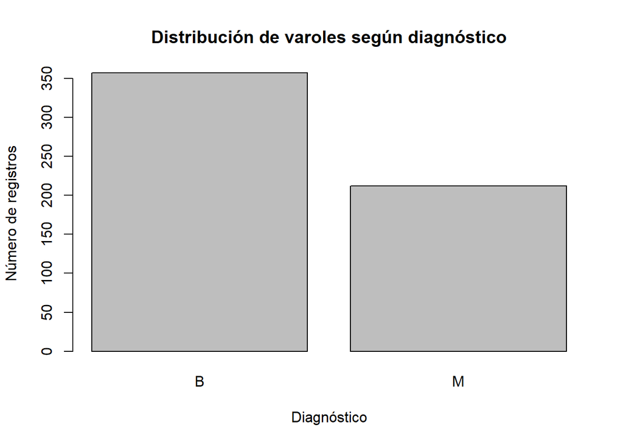

```r
plot(x=cancer$diagnosis, main ="Distribución de varoles según diagnóstico", xlab = "Diagnóstico", ylab = "Número de registros")
```

Se observa que existen más observaciones de muestras benignas que malignas.

Vamos a realizar un par de gráficas para ver la distribución de las varaibles en base a la variable objetivo.

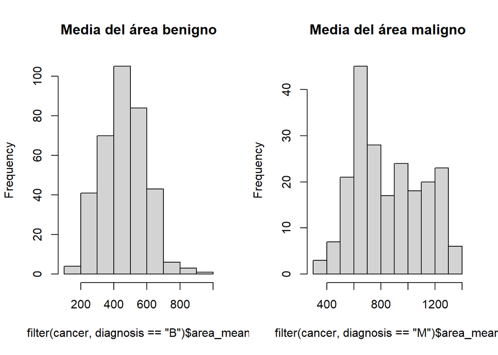

```r
par(mfrow = c(1, 2))
hist(filter(cancer, diagnosis == "B")$area_mean, main = "Media del área benigno")
hist(filter(cancer, diagnosis == "M")$area_mean, main = "Media del área maligno")
```

Se obsserva que la distribución de la media del área del tumor toma valores mayores en el caso de los tumores malignos. Se realizan los mismos gráficos con un par de variables más.

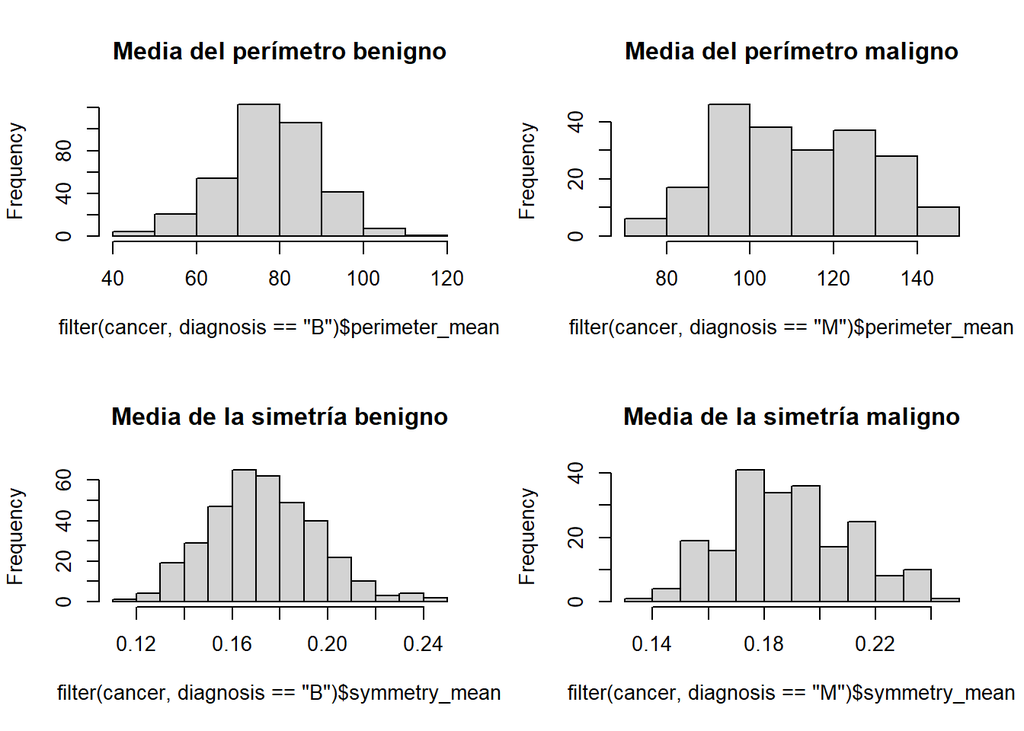

```r
par(mfrow = c(2, 2))
hist(filter(cancer, diagnosis == "B")$perimeter_mean, main = "Media del perímetro benigno")
hist(filter(cancer, diagnosis == "M")$perimeter_mean, main = "Media del perímetro maligno")
hist(filter(cancer, diagnosis == "B")$symmetry_mean, main = "Media de la simetría benigno")
hist(filter(cancer, diagnosis == "M")$symmetry_mean, main = "Media de la simetría maligno")
```

También se nota la diferencia en la distribución de valores para el perímetro, mientras que en la simetría la diferencia es menos notable.

## 4.2. Comprobación de la normalidad y homogeneidad de la varianza

Para la comprobación de la normalidad utilizaremos el test de Shapiro-Wilk.

De esa forma comparamos los p-valor obtenidos con $\alpha$ = 0, 05. Si el valor obtenido para cada variable es mayor, esta sigue una distribución normal y si no es el caso, lo mostramos en la salida.

```r
alpha = 0.05
col.names = colnames(cancer)

for (i in 1:ncol(cancer)) {
  if (i == 1) cat("Variables que no siguen una distribución normal y su p-value:\n")
  if (is.integer(cancer[,i]) | is.numeric(cancer[,i])) {
    p_val = shapiro.test(cancer[,i])$p.value
    if (p_val < alpha) {
      cat(col.names[i])
      cat("(")
      cat(p_val)
      cat(")")
      # Format output
      if (i < ncol(cancer) - 1) cat(", ")
      if (i %% 3 == 0) cat("\n")
    }
  }
}
```

```
## Variables que no siguen una distribución normal y su p-value:
## id(3.07445e-43), radius_mean(7.460958e-12),
## texture_mean(5.195521e-05), perimeter_mean(3.02881e-12), area_mean(1.206725e-17),
## compactness_mean(9.871618e-13), concavity_mean(3.043752e-18),
## concave.points_mean(8.317034e-18), symmetry_mean(0.0131504), fractal_dimension_mean(1.132071e-08),
## radius_se(6.060747e-18), texture_se(9.830276e-09), perimeter_se(7.199905e-17),
## area_se(7.553385e-23), smoothness_se(2.431925e-09), compactness_se(3.783127e-15),
## concavity_se(1.437786e-12), concave.points_se(0.000152261), symmetry_se(1.84265e-12),
## fractal_dimension_se(5.191323e-14), radius_worst(4.11553e-15), texture_worst(0.0001471121),
## perimeter_worst(4.780865e-15), area_worst(5.140758e-20), smoothness_worst(0.01133407),
## compactness_worst(9.694684e-14), concavity_worst(6.459841e-14), concave.points_worst(1.984878e-10),
## symmetry_worst(0.003773075)fractal_dimension_worst(9.326099e-11)
```

Veamos un ejemplo gráfico para la variable cancer$symmetry_mean (p-valor más elevado)

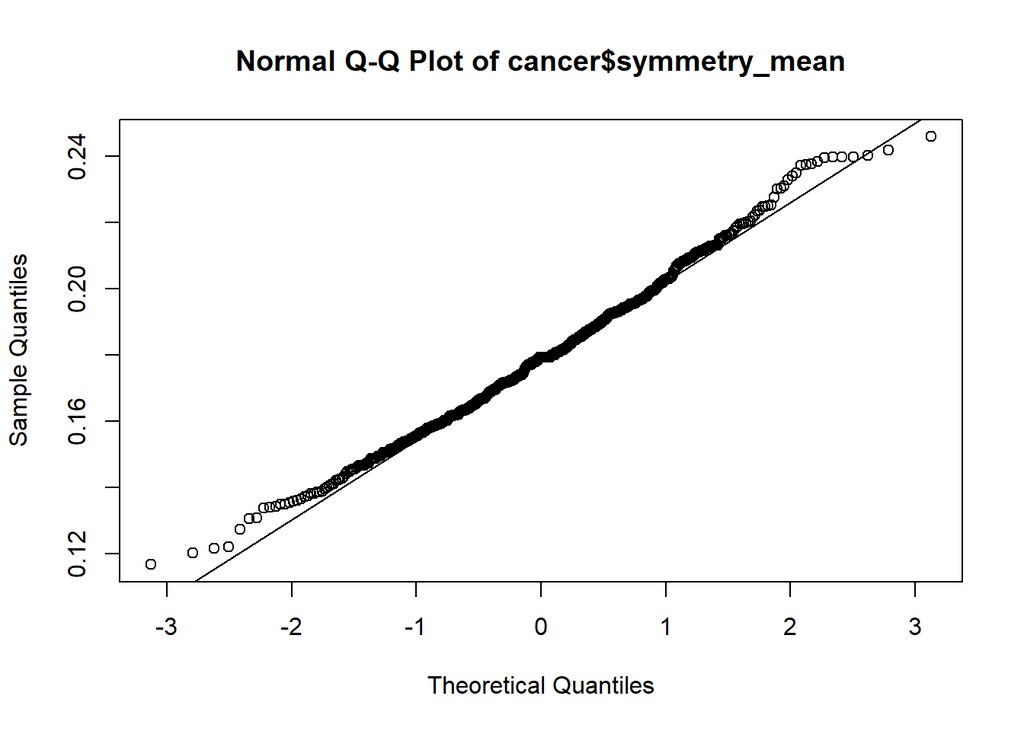

```r
qqnorm(y = cancer$symmetry_mean, main = "Normal Q-Q Plot of cancer$symmetry_mean")
qqline(y = cancer$symmetry_mean)
```

Veamos un ejemplo gráfico para la variable cancer$area_se (p-valor más bajo)

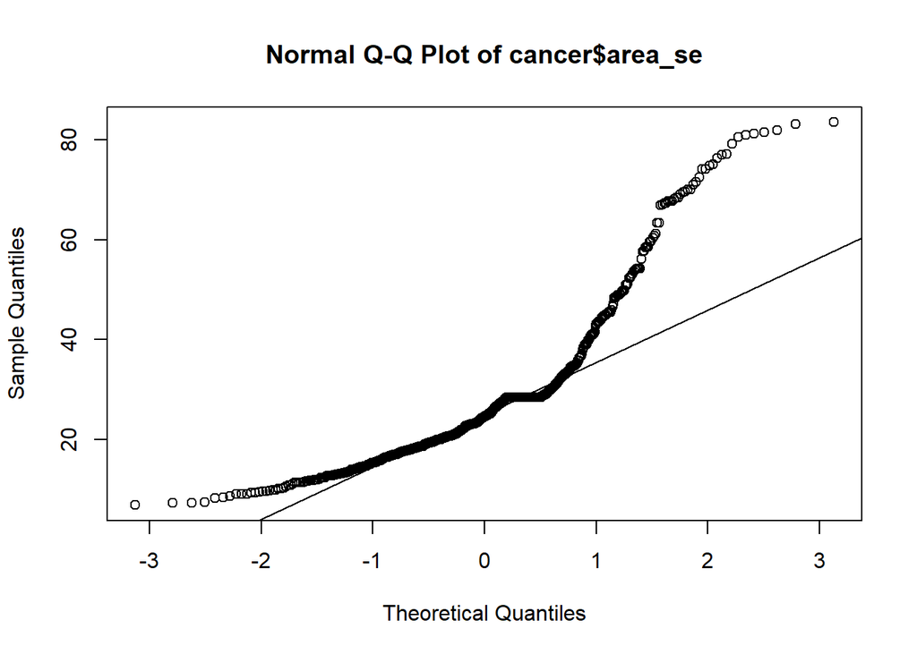

```r
qqnorm(y = cancer$area_se, main = "Normal Q-Q Plot of cancer$area_se")
qqline(y = cancer$area_se)
```

Seguidamente, pasamos a estudiar la homogeneidad de varianzas mediante la aplicación de un test de Fligner-Killeen.

Para poder utilizar esta función, deberemos convertir la variable **diagnosis** de factor a numérica, por lo que crearemos una nueva columna en la cual el valor “1” representa “B” y el valor “2” representa “M”.

```r
library(stats)
cancer$diagnosis_num <- as.numeric(cancer$diagnosis)
fligner.test(diagnosis_num ~ radius_mean, data = cancer)
```

```
##
##  Fligner-Killeen test of homogeneity of variances
##
## data:  diagnosis_num by radius_mean
## Fligner-Killeen:med chi-squared = 467.9, df = 442, p-value = 0.1902
```

```r
fligner.test(diagnosis_num ~ interaction(radius_mean+texture_mean+perimeter_mean+area_mean+smoothness_mean+compactness_mean+concavity_mean+concave.points_mean+symmetry_mean+fractal_dimension_mean), data = cancer)
```

```
##
##  Fligner-Killeen test of homogeneity of variances
##
## data:  diagnosis_num by interaction(radius_mean + texture_mean + perimeter_mean + area_mean + smoothness_mean + compactness_mean + concavity_mean + concave.points_mean + symmetry_mean + fractal_dimension_mean)
## Fligner-Killeen:med chi-squared = NaN, df = 568, p-value = NA
```

Puesto que obtenemos un p-valor superior a 0.05 en el primer caso, aceptamos la hipótesis de que las varianzas de ambas muestras son homogéneas.

## 4.3. Aplicación de pruebas estadísticas para comparar los grupos de datos

### 4.3.1. Análisis de correlación entre variables

```r
corr_matrix <- matrix(nc = 2, nr = 0)
colnames(corr_matrix) <- c("estimate", "p-value")
# Calcular el coeficiente de correlación para cada variable cuantitativa
# con respecto al campo "diagnosis_num"
for (i in 1:(ncol(cancer) - 1)) {
  if (is.integer(cancer[,i]) | is.numeric(cancer[,i])) {
    spearman_test = cor.test(cancer[,i],
    cancer$diagnosis_num,
    method = "spearman" , exact=FALSE)
    corr_coef = spearman_test$estimate
    p_val = spearman_test$p.value
    # Add row to matrix
    pair = matrix(ncol = 2, nrow = 1)
    pair[1][1] = corr_coef
    pair[2][1] = p_val
    corr_matrix <- rbind(corr_matrix, pair)
    rownames(corr_matrix)[nrow(corr_matrix)] <- colnames(cancer)[i]
  }
}

corr_matrix[order(corr_matrix[,"estimate"]), ]
```

```
##                            estimate       p-value
## symmetry_se             -0.13351626  1.412136e-03
## id                      -0.07986636  5.691505e-02
## fractal_dimension_mean  -0.02220746  5.970616e-01
## smoothness_se           -0.01861251  6.577371e-01
## texture_se               0.02858125  4.962456e-01
## fractal_dimension_se     0.21967330  1.201329e-07
## fractal_dimension_worst  0.27959820  1.116014e-11
## symmetry_mean            0.31955798  5.645390e-15
## symmetry_worst           0.33473538  2.305978e-16
## smoothness_mean          0.36789763  1.119210e-19
## compactness_se           0.39221849  2.295020e-22
## smoothness_worst         0.41980396  1.068080e-25
## texture_mean             0.45736834  9.246165e-31
## texture_worst            0.46399560  1.012646e-31
## concave.points_se        0.48485355  6.943224e-35
## concavity_se             0.48863154  1.757207e-35
## radius_se                0.55479887  3.051137e-47
## perimeter_se             0.55985637  2.976668e-48
## compactness_worst        0.57778203  5.593289e-52
## compactness_mean         0.57849012  3.942091e-52
## area_se                  0.62834594  7.765199e-64
## concavity_worst          0.70022692  4.992761e-85
## area_mean                0.70704341  2.263673e-87
## radius_mean              0.71482087  3.953044e-90
## concavity_mean           0.72925855  1.674819e-95
## perimeter_mean           0.73469136  1.291877e-97
## area_worst               0.75910665 8.545924e-108
## concave.points_mean      0.76947017 1.717687e-112
## radius_worst             0.77289494 4.248707e-114
## concave.points_worst     0.78167359 2.387021e-118
## perimeter_worst          0.78470761 7.289042e-120
```

## 4.3.2. Contraste de hipótesis

En este segundo modelo se quiere determinar si el ser diagnosticado depende del perimeter_mean (tamaño medio del tumor central), si éste tiene un valor inferior de 92.

```r
cancer.low.perimeter_mean <- cancer[cancer$perimeter_mean <= 92,]$diagnosis_num
cancer.high.perimeter_mean <- cancer[cancer$perimeter_mean > 92,]$diagnosis_num

#Escalamos para normalizar
cancer.low.perimeter_mean <- scale(cancer.low.perimeter_mean,center=T,scale=T)
cancer.high.perimeter_mean <- scale(cancer.high.perimeter_mean,center=T,scale=T)

t.test(cancer.low.perimeter_mean, cancer.high.perimeter_mean, alternative = "less")
```

```
##
##  Welch Two Sample t-test
##
## data:  cancer.low.perimeter_mean and cancer.high.perimeter_mean
## t = -3.0128e-15, df = 446.19, p-value = 0.5
## alternative hypothesis: true difference in means is less than 0
## 95 percent confidence interval:
##       -Inf 0.1427813
## sample estimates:
##     mean of x     mean of y
## -1.048615e-17  2.504940e-16
```

Puesto que obtenemos un p-valor superior a 0.05, damos por buena la hipótesis.

## 4.3.3. Modelo de regresión lineal

Un tercer modelo es la regresión lineal. Entre los diferentes modelos, calcularemos su coeficiente de determinación (R2) para posteriormente realizar una predicción.

```r
# Regresores cuantitativos con mayor coeficiente
# de correlación con respecto al precio
corr1 = cancer$perimeter_worst
corr2 = cancer$concave.points_worst
corr3 = cancer$radius_worst
corr4 = cancer$concave.points_mean
corr5 = cancer$area_worst
corr6 = cancer$perimeter_mean
corr7 = cancer$concavity_mean
corr8 = cancer$radius_mean
# Variable a predecir
diagnostico = cancer$diagnosis_num
# Generación de varios modelos
modelo1 <- lm(diagnostico ~ corr1 + corr2 + corr3 + corr4 + corr5 + corr6 + corr7 + corr8, data = cancer)
modelo2 <- lm(diagnostico ~ corr1 + corr2 + corr4 + corr6, data = cancer)
modelo3 <- lm(diagnostico ~ corr1 + corr2 + corr3 + corr5, data = cancer)
modelo4 <- lm(diagnostico ~ corr4 + corr6 + corr7 + corr8, data = cancer)
```

Para los anteriores modelos de regresión lineal múltiple obtenidos, podemos utilizar el coeficiente de determinación para medir la bondad de los ajustes y quedarnos con aquel modelo que mejor coeficiente presente.

```r
# Tabla con los coeficientes de determinación de cada modelo
tabla.coeficientes <- matrix(c(1, summary(modelo1)$r.squared,
2, summary(modelo2)$r.squared,
3, summary(modelo3)$r.squared,
4, summary(modelo4)$r.squared),
ncol = 2, byrow = TRUE)
colnames(tabla.coeficientes) <- c("Modelo", "R^2")
tabla.coeficientes
```

```
##      Modelo       R^2
## [1,]      1 0.7334748
## [2,]      2 0.7089986
## [3,]      3 0.7219513
## [4,]      4 0.6659149
```

En este caso, el primer modelo tiene un mayor coeficiente de determinación. Ahora, empleando este modelo, realizaremos predicciones:

```r
newdata1 <- data.frame(
  corr1 = 184.60,
  corr2 = 0.26540,
  corr3 = 25.38,
  corr4 = 0.14710,
  corr5 = 2019,
  corr6 = 122.80,
  corr7 = 0.30010,
  corr8 = 17.990
)

newdata2 <- data.frame(
  corr1 = 65.13,
  corr2 = 0.06227,
  corr3 = 10.23,
  corr4 = 0.02076,
  corr5 = 314.9,
  corr6 = 60.34,
  corr7 = 0.02956,
  corr8 = 9.504
)

# Predecir el diagnostico
predict(modelo1, newdata1)
```

```
##        1
## 2.712086
```

```r
predict(modelo1, newdata2)
```

```
##         1
## 0.9233966
```

Como vemos, en estos ejemplos con valores del propio dataset, las prediciones son cercanas a “2” y a “1” respectivamente, tal y como esos mismos registros tienen informado en la variable **diagnosis_num**. Los registros son el 1 y el 22.

# 5. Representación de los resultados a partir de tablas y gráficas.

Este apartado se ha respondido a lo largo de la práctica.

# 6. Resolución del problema. A partir de los resultados obtenidos, ¿cuáles son las conclusiones? ¿Los resultados permiten responder al problema?

A la luz de los resultados mostrados en cada uno de los apartados anteriores, mediante el uso del dataset indicado, podemos concluir que mediante un modelo de regresión lineal podemos realizar predicciones para la detección del cáncer de mama.

# Contribucción

```r
Contribuciones <- c("Investigación previa", "Redacción de las respuestas", "Desarrollo código")
Firmas <- c("CRS, YFR", "CRS, YFR", "CRS, YFR")
tabla <- data.frame(cbind(Contribuciones, Firmas))
knitr::kable(tabla)
```

| Contribuciones | Firmas |
| --- | --- |
| Investigación previa | CRS, YFR |
| Redacción de las respuestas | CRS, YFR |
| Desarrollo código | CRS, YFR |

# Export fichero final

```r
write.csv(cancer, file ="./data_clean.csv")
```